# Smith lab Durham

Laboratory for invertebrate palaeontology and phylogenetics

# Martin Smith

## Laboratory for invertebrate palaeontology and phylogenetics

I am interested in the origins of biodiversity.  
My work includes the study of unusual organisms from [Burgess Shale](http://burgess-shale.rom.on.ca/en/)-type deposits and their microscopic counterparts, the [Small Carbonaceous Fossils](http://en.wikipedia.org/wiki/Small_Carbonaceous_Fossil). I also have an interest in the preservation of these remarkable fossils, and the mathematical techniques used to reconstruct evolutionary history from palaeontological evidence.

Research Phd/MSc projects Teaching Biography

### Solving the riddle of the hyoliths

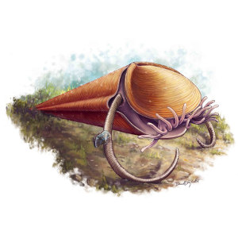

Danielle Dufault

Hyoliths are one of the most abundant fossils from the Palaeozoic, the era before the dinosaurs. Looking like an ice cream cone with a lid, their identity has long been a mystery: were they aberrant snails, or a long-extinct lineage with no close relatives – a ‘failed evolutionary experiment’?

Amazing new fossils from North America and China have finally solved this 175 year old mystery. Preserving the body, not just the shell, these fossils reveal for the first time a crown of tentacles surrounding the mouth – a distinctive feature that links the fossils to modern brachiopods and horseshoe worms. This shows that Hyoliths lived on the sea floor, plucking food particles from passing water. Settling the affinity of hyoliths sheds new light on the origins of animal body plans during the sudden burst of evolution that is the Cambrian Explosion.

Moysiuk, J., Smith, M.R. & Caron, J-B. (2017). “Hyoliths are Palaeozoic lophophorates”. *Nature* **541**: 394–397.

Sun, H.-J., Smith, M.R., Zeng, H., Zhao, F.-Z., Li, G.-X. & Zhu, M.-Y. (2018). “Hyoliths with pedicles illuminate the origin of the brachiopod body plan”. *Proc. Roy. Soc. B*, **285**: 20181780.

### The humble fungus that brought life to land

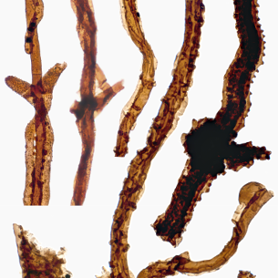

M. R. Smith

These tiny branching filaments may look unremarkable, but they represent the oldest fossils of terrestrial organisms. New fossils collected in field excursions to Sweden, New York and Scotland allowed me to reconstruct how the hitherto enigmatic organism *Tortotubus* lived and grew.

These strands represent fragments of extensive subterranean networks, which would have stabilised and nourished the soils in which early plants took root.

Smith, M.R. (2016). “[Cord-forming Palaeozoic fungi in terrestrial assemblages](http://doi.org/10.1111/boj.12389)”. *Botanical Journal of the Linnean Society* **180** (4): 452–460.

### Mini fossils that pack a punch

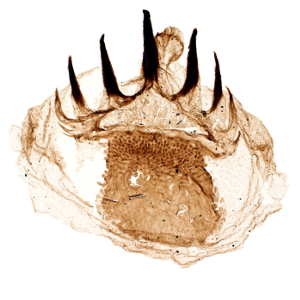

T.H.P. Harvey / PalAss

Small Carbonaceous Fossils (SCFs) are a diverse suite of non-mineralized microfossils representing bits of early organisms. Widespread in space and time, these tiny elements provide an unrivalled view on the rate and tempo of Cambrian evolution. By establishing the identity of a range of problematic SCFs, my research is telling the evolutionary tales locked up in these beautiful fossils.

Smith, M.R., Hughes, G.M.G., Vargas, M.C. & de la Parra, F. (2016). “[Sclerites and possible mouthparts of *Wiwaxia* from the temperate palaeolatitudes of Colombia, South America](http://doi.org/10.1111/let.12154)”. *Lethaia* **49** (3): 393-397.

Smith, M.R., Harvey, T.H.P. & Butterfield, N.J. (2015). “[The macro-and micro-fossil record of the Cambrian priapulid *Ottoia*](http://doi.org/10.1111/pala.12168)”. *Palaeontology* **58** (4): 705–721.

Caron, J.-B., Smith, M.R. & Harvey, T.H.P. (2013). “[Beyond the Burgess Shale: Cambrian microfossils track the rise and fall of hallucigeniid lobopodians](http://rspb.royalsocietypublishing.org/content/280/1767/20131613.abstract)”. *Proceedings of the Royal Society B* **280** (1767): 20131613.

### The ‘weird worm’ *Hallucigenia*

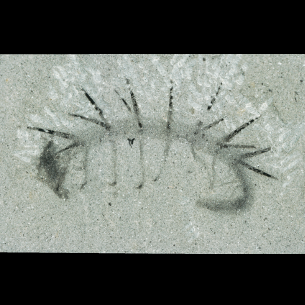

M. R. Smith / Smithsonian

*Hallucigenia* has always baffled scientists.  
A 500-million-year-old enigma, this bizarre spiny worm is known from a handful of fossils and just two locations. A study with coauthors Tom Harvey and Jean-Bernard Caron revealed that, in fact, it had relatives all over the world. Whilst examining its defensive spines, we spotted a resemblance with a global family of small spiny fossils: both have a subtle surface ornament and a structure like a stack of ice-cream cones. It seems that quirky *Hallucigenia* was no recluse: along with its relatives, it formed a cosmopolitan community that spanned the Cambrian seas.

[video not shown]

When *Hallucigenia* was first described in the 1970s, the spines along its back were mistaken for legs, and its head was mistaken for its tail. Now, state-of-the-art electron microscopes have yielded new details from the spines, claws and head of *Hallucigenia*, exposing its [place in life’s evolutionary tree](https://theconversation.com/page-43721), and how it helps us to [reconstruct the common ancestor of all moulting animals](https://theconversation.com/page-30438).

Smith, M.R. (2017). “[Fossil Focus: *Hallucigenia* and the origin of animal body plans](http://www.palaeontologyonline.com/articles/2017/fossil_focus_hallucigenia)”. *Palaeontology Online* **7** (5): 1–9

Smith, M.R. & Caron, J.-B. (2015). “[*Hallucigenia*’s head and the pharyngeal armature of early ecdysozoans](http://rdcu.be/dcCi)”. *Nature* **523** (7558): 75–78.

Caron, J.-B., Smith, M.R. & Harvey, T.H.P. (2013). “[Beyond the Burgess Shale: Cambrian microfossils track the rise and fall of hallucigeniid lobopodians](http://rspb.royalsocietypublishing.org/content/280/1767/20131613.abstract)”. *Proceedings of the Royal Society B* **280** (1767): 20131613.

### The ‘maybe mollusc’ *Wiwaxia*

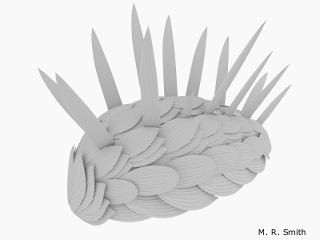

M.R. Smith

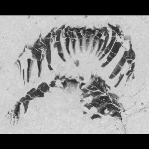

M.R. Smith / Royal Society

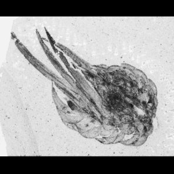

M.R. Smith / Palaeontology

The loveable fossil *Wiwaxia* bears an intimidating coat of scale-mail armour punctuated with lengthy spines. But what is the animal underneath this tough exterior? Could it be a slug, related to the molluscs? Or does it really represent an ‘earthworm in disguise’? I’ve focussed on two clues to assess its affinity. Firstly, its mouthparts have several similarities with the teeth of modern molluscs - and look nothing like worm teeth. Secondly, the animal grows just like some slug-like molluscs that inhabit modern rock pools. However, compelling links with annelid worms suggest that *Wiwaxia* has a deep evolutionary position and might tell us how both these two body plans became established.

Zhang, Z.-F., Smith, M.R. & Shu, D.-G. (2015). “[New reconstruction of the *Wiwaxia* scleritome, with data from Chengjiang juveniles](http://doi.org/10.1038/srep14810)”. *Scientific Reports* **5**: 14810.

Zhao, F.-C., Smith, M.R., Yin, Z.-J., Zeng, H., Hu, S.-X., Li, G.-X. & Zhu, M.-Y. (2015). “[First report of *Wiwaxia* from the Cambrian Chengjiang Lagerstätte](http://doi.org/10.1017/S0016756814000648)”. *Geological Magazine* **152**: 378–382.

Smith, M.R. (2014). “[Ontogeny, morphology and taxonomy of the soft-bodied Cambrian “mollusc” *Wiwaxia*](http://onlinelibrary.wiley.com/doi/10.1111/pala.12063/abstract)", *Palaeontology* **57** (1): 215-229.

Smith, M.R. (2012). “[Mouthparts of the Burgess Shale fossils *Odontogriphus* and *Wiwaxia*: implications for the ancestral molluscan radula](http://rspb.royalsocietypublishing.org/content/279/1745/4287)”, *Proceedings of the Royal Society B: Biological Sciences* **279** (1745): 4287-4295.

### The ‘squishy squid’ *Nectocaris*

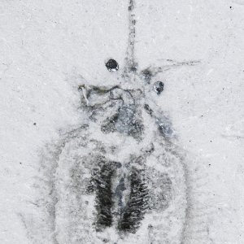

M.R. Smith / Nature

From 1911, only a single specimen of *Nectocaris* was known. But since the 1980s, Royal Ontario Museum collectors have recovered dozens more. This new material transformed our idea of what *Nectocaris* looked like, and colleague Jean-Bernard Caron and I estabilshed that it resembled a modern-day squid or cuttlefish. This was astonishing: such cephalopods aren’t meant to have evolved until much, much later.  
This could mean that there’s a huge (200 million year) gap in the fossil record, which would turn the conventional concept of cephalopod evolution on its head. Alternatively, *Nectocaris* may represent an incredible example of convergent evolution - the independent invention of a modern body plan. This question hinges on how far we trust the fossil record; for now, at least, the jury is out.

Smith, M.R. (2020). “An Ordovician nectocaridid hints at an endocochleate origin of Cephalopoda”. *Journal of Paleontology* **94** (1): 64–69.

Smith, M.R. & Caron, J-B. (2011). “[*Nectocaris* and early cephalopod evolution: Reply to Mazurek & Zatoń](http://onlinelibrary.wiley.com/doi/10.1111/j.1502-3931.2011.00295.x/abstract)”. *Lethaia* **44** (4): 369–372.

Smith, M.R. & Caron, J.-B. (2010). “[Primitive soft-bodied cephalopods from the Cambrian](http://rdcu.be/bKoH)”, *Nature* **465** (7297): 469–472.

### The ‘soggy seaweed’ *Nematothallus*

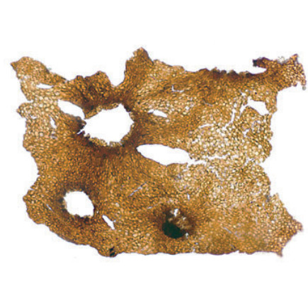

M.R. Smith / Palaeontology

Tiny fragments of fossilized cuticle, referred to as *Nematothallus*, have long been implicated in the origin of land plants. Cuticle was an essential adaptation before plants could invade the land – without it, they’d dry up far too quickly. But plants are not the only organisms to have cuticle – so do some seaweeds, lichens, fungi, and animals. How can you tell the difference based on fossil scraps that are less than a millimeter in size?

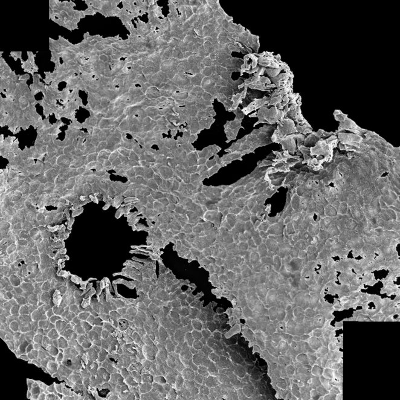

M.R. Smith / Palaeontology

With co-author Nick Butterfield, I recovered new details of *Nematothallus*’s reproductive organs, some of which were even preserved with spores attached. Details of these organs allowed our fossils to be reinterpreted as coralline red algae, a type of seaweed that forms parts of coral reefs today. But unlike their modern counterparts, our fossils did not lay down limestone in their skeletons — filling an interesting gap in the evolutionary history of seaweeds.

Smith, M.R. & Butterfield, N.J. (2013). “[A new view on *Nematothallus*: coralline red algae from the Silurian of Gotland](http://onlinelibrary.wiley.com/doi/10.1111/j.1475-4983.2012.01203.x/abstract)”. *Palaeontology* **56** (2): 297-321.

After obtaining an undergraduate degree (BA and MSc) in Natural Sciences from the University of Cambridge, specializing in [Earth Sciences](http://www.esc.cam.ac.uk/) and undertaking a Masters’ research project in Palaeobotany with [Nick Butterfield](http://www.esc.cam.ac.uk/directory/nicholas-butterfield).

I then proceeded to a PhD at the University of Toronto under [Jean-Bernard Caron](https://www.rom.on.ca/en/collections-research/rom-staff/jean-bernard-caron). Based at the [Royal Ontario Museum](https://www.rom.on.ca/), this was my first encounter with the [Burgess Shale](http://burgess-shale.rom.on.ca/en/index.php) fossils that now form a central part of my research portfolio. I subsequently returned to Cambridge to take up a Junior Research Fellowship at [Clare College](http://www.clare.cam.ac.uk/), before moving in 2015 to Durham University, where I am an Assistant Professor (i.e. Lecturer) in Palaeontology.

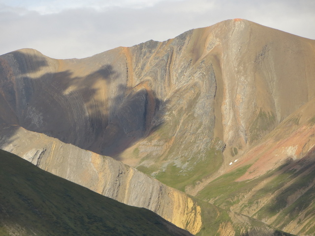

I am currently looking to recruit excellent students to our doctoral and Master of Science by Research programmes.

A diverse range of postgraduate projects are available, based on independent fieldwork, museum collections, and laboratory-based data analysis.

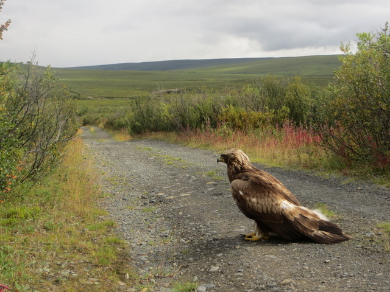

A [full listing](https://www.dur.ac.uk/earth.sciences/postgraduate/research/palaeoecosystems/) is maintained at the Durham [Palaeoecoystems Lab](https://www.dur.ac.uk/earth.sciences/postgraduate/research/palaeoecosystems/) page; do get in touch to discuss these or other ideas further.

As a Senior Fellow of the Higher Education Academy, I apply evidence-based pedagogical theory to develop an engaging, balanced and outcome-directed teaching approach.

[figure not shown]

Jiahe Max Luan

I currently lead a second year undergraduate course in Palaeoecosystems, contribute to Palaeobiology teaching at a first-year introductory level, and supervise third- and fourth-year research projects.

- Example practical exercise (with notes): research-led investigation of Ediacaran organisms.

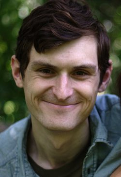

### Contact

Dr. Martin R. Smith  
Assistant Professor (Palaeontology)  
Department of Earth Sciences  
University of Durham, DH1 3LE  
Room ES313

+44 (0) 191 334 2320  
martin.smithdurhamacuk

[figure not shown]

[Follow @PalaeoSmith](https://twitter.com/PalaeoSmith)

### Selected Papers All

**Smith, M.R.** (2020). “[Information theoretic Generalized Robinson-Foulds metrics for comparing phylogenetic trees](https://dx.doi.org/10.1093/bioinformatics/btaa614)”. *Bioinformatics*, in the press.

**Smith, M.R.** (2020). “[Finding a home for hyoliths](https://dx.doi.org/10.1093/nsr/nwz194)”. *National Science Review*, **7** 470–471.

Yang, J., **Smith, M.R.**, Zhang, X.-G. & Yang, X.-Y. (2020). “[Introvert and pharynx of *Mafangscolex*, a Cambrian palaeoscolecid](https://www.cambridge.org/core/journals/geological-magazine/article/introvert-and-pharynx-of-mafangscolex-a-cambrian-palaeoscolecid/3B38DE80547ED18D9F9A453B50477E39)”. *Geological Magazine*, in the press.

**Smith, M.R.** (2020). “An Ordovician nectocaridid hints at an endocochleate origin of Cephalopoda”. *Journal of Paleontology*, **94** (1): 64–69.

Asher, R., **Smith, M.R.**, Rankin, A. & Emry, R. (2019). “[Congruence, fossils, and the evolutionary tree of rodents and lagomorphs](http://dx.doi.org/10.1098/rsos.190387)”. *Royal Society Open Science*, **6** (7): 190387.

Brazeau, M.D., Guillerme, T. & **Smith, M.R.** (2019). “[An algorithm for morphological phylogenetic analysis with inapplicable data](https://dx.doi.org/10.1093/sysbio/syy083)”. *Systematic Biology*, **68** (4): 619–631.

**Smith, M.R.** (2019). “[Bayesian and parsimony approaches reconstruct informative trees from simulated morphological datasets](http://dx.doi.org/10.1098/rsbl.2018.0632)”. *Biology Letters*, **15**:20180632.

Sun, H.-J., **Smith, M.R.**, Zeng, H., Zhao, F.-Z., Li, G.-X. & Zhu, M.-Y. (2018). “Hyoliths with pedicles illuminate the origin of the brachiopod body plan”. *Proc. Roy. Soc. B*, **285**: 20181780.

Zhao, F.-C., **Smith, M.R.**, Yin, Z.-J., Zeng, H., Li, G. X., & Zhu, M.-Y. (2017). “[*Orthrozanclus elongata* n. sp. and the significance of sclerite-covered taxa for early trochozoan evolution](http://dx.doi.org/10.1038/s41598-017-16304-6)”. *Scientific Reports* **7** 16232.  
Data supplements: [[1]](https://doi.org/10.6084/m9.figshare.c.3841387) [[2]](https://doi.org/10.6084/m9.figshare.5501596)

Moysiuk, J., **Smith, M.R.** & Caron, J-B. (2017). “Hyoliths are Palaeozoic lophophorates”. *Nature* **541**: 394–397.

**Smith, M.R.** (2016). “[Evolution: Velvet worm biogeography](http://doi.org/10.1016/j.cub.2016.07.067)”. *Current Biology* **26** (19): R882–R884.

Zhang, X.-G., **Smith, M.R.**, Yang, J. & Hou, J.-B. (2016). “[Onychophoran-like musculature in a phosphatized Cambrian lobopodian](http://dx.doi.org/10.1098/rsbl.2016.0492)”. *Biology Letters* **12** (9): 20160492

**Smith, M.R.** (2016). “[Cord-forming Palaeozoic fungi in terrestrial assemblages](http://doi.org/10.1111/boj.12389)”. *Botanical Journal of the Linnean Society* **180** (4): 452–460.

**Smith, M.R.**, Hughes, G.M.G., Vargas, M.C. & de la Parra, F. (2016). “[Sclerites and possible mouthparts of *Wiwaxia* from the temperate palaeolatitudes of Colombia, South America](http://doi.org/10.1111/let.12154)”. *Lethaia* **49** (3): 393-397.

- **Smith, M.R.** (2015). “[A palaeoscolecid worm from the Burgess Shale](http://doi.org/10.1111/pala.12210)”. *Palaeontology* **58** (6): 973–979.

Zhang, Z.-F., **Smith, M.R.** & Shu, D.-G. (2015). “[New reconstruction of the *Wiwaxia* scleritome, with data from Chengjiang juveniles](http://doi.org/10.1038/srep14810)”. *Scientific Reports* **5**: 14810.

**Smith, M.R.** & Caron, J.-B. (2015). “[*Hallucigenia*’s head and the pharyngeal armature of early ecdysozoans](http://rdcu.be/dcCi)”. *Nature* **523** (7558): 75–78.

**Smith, M.R.**, Harvey, T.H.P. & Butterfield, N.J. (2015). “[The macro-and micro-fossil record of the Cambrian priapulid *Ottoia*](http://doi.org/10.1111/pala.12168)”. *Palaeontology* **58** (4): 705–721.  
[[Data supplement](https://doi.org/10.5061/dryad.km109)]

Zhao, F.-C., **Smith, M.R.**, Yin, Z.-J., Zeng, H., Hu, S.-X., Li, G.-X. & Zhu, M.-Y. (2015). “[First report of *Wiwaxia* from the Cambrian Chengjiang Lagerstätte](http://doi.org/10.1017/S0016756814000648)”. *Geological Magazine* **152**: 378–382.

**Smith, M.R.** & Ortega Hernández, J. (2014). “[*Hallucigenia*’s onychophoran-like claws and the case for Tactopoda](http://rdcu.be/bKoD)”. *Nature* **514** (7522): 363–366.

Yang, J., **Smith, M.R.**, Lan, T, Hou, J.-B., Zhang, X.-G. (2014). “[Articulated *Wiwaxia* from the Cambrian Stage 3 Xiaoshiba Lagerstätte](http://dx.doi.org/10.1038/srep04643)”. *Scientific Reports* **4**: 4643.

**Smith, M.R.** (2014). “[Ontogeny, morphology and taxonomy of the soft-bodied Cambrian “mollusc” *Wiwaxia*](http://onlinelibrary.wiley.com/doi/10.1111/pala.12063/abstract)". *Palaeontology* **57** (1): 215–229.

Caron, J.-B., **Smith, M.R.** & Harvey, T.H.P. (2013). “[Beyond the Burgess Shale: Cambrian microfossils track the rise and fall of hallucigeniid lobopodians](http://rspb.royalsocietypublishing.org/content/280/1767/20131613.abstract)”. *Proceedings of the Royal Society B* **280** (1767): 20131613.

View colour PDF (22 MB) / [Supp. Imgs.](http://datadryad.org/resource/doi:10.5061/dryad.7m6kg)

**Smith, M.R.** (2013). “[Likelihood and Parsimony diverge at high taxonomic levels](http://onlinelibrary.wiley.com/doi/10.1111/cla.12017/abstract)”. *Cladistics* **29**: 463.

**Smith, M.R.** & Butterfield, N.J. (2013). “[A new view on *Nematothallus*: coralline red algae from the Silurian of Gotland](http://onlinelibrary.wiley.com/doi/10.1111/j.1475-4983.2012.01203.x/abstract)”. *Palaeontology* **56** (2): 297-321.

**Smith, M.R.** (2012). “[Mouthparts of the Burgess Shale fossils *Odontogriphus* and *Wiwaxia*: implications for the ancestral molluscan radula](http://rspb.royalsocietypublishing.org/content/279/1745/4287)”, *Proceedings of the Royal Society B: Biological Sciences* **279** (1745): 4287–4295.

**Smith, M.R.** (2012). “Morphology, ecology, and affinity of soft-bodied ‘molluscs’ from Cambrian Burgess Shale-type deposits”. PhD Thesis (with Appendix), University of Toronto.

**Smith, M.R.** & Caron, J-B. (2011). “[*Nectocaris* and early cephalopod evolution: Reply to Mazurek & Zatoń](http://onlinelibrary.wiley.com/doi/10.1111/j.1502-3931.2011.00295.x/abstract)”. *Lethaia* **44** (4): 369–372.

**Smith, M.R.** and Caron, J.-B. (2010). “[Primitive soft-bodied cephalopods from the Cambrian](http://rdcu.be/bKoH)”, *Nature* **465** (7297): 469–472.

### Links

- International Conference on the Cambrian Explosion (Banff 2009): abstract volume
- Virtual Museum of Canada: [Burgess Shale exhibit](http://burgess-shale.rom.on.ca/en/)